# Beam explorer — transmitter teeth against HFSS and the empirical beams (v0012, reference)

The transmitter comb through the elevation-sweep raster (07-17 20:26–21:28 UTC), compared with the HFSS polarised beam and the empirical PCA and DPSS beams at $\ell_{\max}=8$. Everything is sampled at the same pointing, and residuals are shown for single teeth, as waterfalls across the band, and as per-tooth scores.

- **Product:** `derived/beam/empirical_raster_v0012`, the reference beam since 2026-09-25 (replacing v0011), generated by `data-analysis/scripts/marjum-2026-07/fit_beam.py` with its defaults. That script is a thin driver on `eigsep_data.beam_mapping`, and this notebook evaluates the product through the same package (`TxGeometryModel`, `transmitter_power`, `hfss_power`, `tooth_fields`), so none of its geometry is reimplemented here. v0011, the previous reference, is compared under *Across the band*.
- **Pointing convention (highline):** $\hat v_\mathrm{ENU} = R_z(\psi)\,R_x(\mathrm{el}+\delta_\mathrm{el})\,R_z(\mathrm{az}+\mathrm{offset}+\delta_\mathrm{az})\,\hat v_\mathrm{body}$, with $\psi = 142.164°$ (the highline; `eigsep_base.rotations.mount_rotation`). The body frame has boresight +z and the dipole arm +x. el is 0 at zenith and +90° at the horizon toward compass 37.836°. The fitted az offset (−16°) is the measured offset of the table's az zero from the highline.
- **Pointing:** `curation/pointing_table.parquet` v2.0 (commanded azimuth, IMU elevation).
- **Signal:** each tooth minus a local DPSS background (150 ns delay half-width, 48 MHz windows, tooth ±1 masked, FM excluded, symmetric clipping; `beam_mapping.tx_background`). v0012 keeps DPSS modes to concentration 1e-6 (21 per window), so the background can represent a constant; v0009–v0011 kept 15, which could not. The model is `gain × |E_beam* · e_tx|²`.
- **Teeth:** `derived/beam/tooth_selection_v0002`, 64 teeth over 64.5–240.2 MHz, chosen by two model-free rules (isolation and neighbour coherence). The corrected background selects the same teeth.
- **Masks:** reversal glitches, the gap-ratio dropout mask, and `raster_flags_v0001` (broadband dropouts and spikes; tooth spikes exist only for 145–235 MHz).

The background and tooth choices are documented in `debug/tooth_background_debug.ipynb`, `debug/tooth_background_basis_debug.ipynb` and `debug/tooth_selection_debug.ipynb`.

```python
from pathlib import Path
import json
import os

import numpy as np
import pandas as pd
import matplotlib.pyplot as plt
from matplotlib.colors import LogNorm
import healpy as hp
import pyarrow.parquet as pq

PLOT_BACKEND = os.environ.get('EIGSEP_NOTEBOOK_BACKEND', 'widget')
get_ipython().run_line_magic('matplotlib', PLOT_BACKEND)
os.environ.setdefault('JAX_PLATFORMS', 'cpu')
os.environ.setdefault('JAX_ENABLE_X64', 'true')

ROOT = next(p for p in [Path.cwd(), *Path.cwd().parents]
            if (p / 'marjum-2026-07/data').is_dir())
CAMPAIGN = ROOT / 'marjum-2026-07'

import eigsep_data
from eigsep_data import AntennaResolutionPolicy, MetadataIndex
from eigsep_data.beam_sim import read_beam
eigsep_data.set_campaign_root(CAMPAIGN)

RASTER_UTC = ('2026-07-17 20:26:00', '2026-07-17 21:28:40')
FREQ_MHZ = 156.25            # an HFSS slice; every HFSS slice sits on an even-index comb tooth
PRODUCT = CAMPAIGN / 'derived/beam/empirical_raster_v0012'
PREVIOUS = CAMPAIGN / 'derived/beam/empirical_raster_v0011'   # compared in 'Across the band'

# Pointing, transmitter coupling and the HFSS normalisation come from the package that fitted
# the product (eigsep_data.beam_mapping); the notebook reimplements none of them.
import eigsep_data.beam_mapping as bm
```

```python
# --- the product: pointing, masks and background-subtracted tooth data -------
# The product's data are the tooth minus a local DPSS background, computed by fit_beam.py;
# they are read from the product rather than recomputed here.
import hashlib

provenance = json.loads((PRODUCT / 'provenance.json').read_text())
# Data inputs and artifacts must match exactly. Generator scripts may have changed since
# the fit (code-only edits such as new defaults); those are reported, not asserted.
changed_code = []
for relative_path, expected in provenance['input_sha256'].items():
    same = hashlib.sha256((ROOT / relative_path).read_bytes()).hexdigest() == expected
    if relative_path.endswith('.py'):
        changed_code += [] if same else [relative_path]
    else:
        assert same, relative_path
print('generator scripts changed since the fit:', changed_code or 'none')
assert provenance['convention'] == 'highline', provenance.get('convention')
for relative_path, expected in provenance['artifact_sha256'].items():
    assert hashlib.sha256((PRODUCT / relative_path).read_bytes()).hexdigest() == expected, relative_path
with np.load(PRODUCT / 'pca/diagnostics.npz') as z:
    pca = {key: z[key] for key in z.files}
print('pointing:', provenance['pointing'])
print('background:', provenance['background'])
print('teeth: %d, %.1f-%.1f MHz' % (len(pca['channels']), pca['freqs'].min(), pca['freqs'].max()))

T = pca['t']
AZ = pca['az_table']                              # pointing-table azimuth (commanded)
EL = pca['el']

# --- the default channel -------------------------------------------------------
BEAM_CART, _, HFSS_FREQS = read_beam()
s = int(np.argmin(np.abs(HFSS_FREQS - FREQ_MHZ)))
ch = int(round(HFSS_FREQS[s] / (250.0 / 1024)))
assert ch in pca['channels'], ch
fidx = int(np.flatnonzero(pca['channels'] == ch)[0])
DATA = pca['data'][fidx]
print('channel %d = %.4f MHz; %d samples' % (ch, HFSS_FREQS[s], len(DATA)))
```

```
generator scripts changed since the fit: none
```

```
pointing: marjum-2026-07/pointing_table@v2.0+e0ffa78-dirty
background: {'method': 'local DPSS (eigsep_data.beam_mapping.tx_background)', 'halfwidth_ns': 150.0, 'window_mhz': 48.0, 'excluded_mhz': [87.0, 108.5], 'limits_mhz': [40.0, 249.5], 'concentration_min': 1e-06}
teeth: 64, 64.5-240.2 MHz
channel 640 = 156.2500 MHz; 6845 samples
```

```python
# --- geometry and the HFSS model at the same coordinates --------------------
ARM = int(pca['arms'][fidx])
FIT_OK = pca['good'][fidx].astype(bool)          # dropout mask, raster flags
print('%d samples fitted; %d raster-flagged samples removed' % (FIT_OK.sum(), pca['sample_flag'].sum()))
SPLIT = pca['split']                              # 12-deg stripes of commanded az: 0 train, 1 val, 2 test
TRAIN = FIT_OK & (SPLIT == 0)
PARAMS = pca['params']                            # geometry corrections, bm.PARAM_NAMES
pa = PARAMS[0]
print('az offset %+.1f deg; geometry (%s): %s' % (pca['az_offset_deg'], provenance['geometry_model'],
      {k: round(v, 3) for k, v in provenance['geometry'].items()}))

ant = json.loads((CAMPAIGN / 'imgs/fits/v0001_marjum_geometry/shared.json').read_text())['antenna_91m_era']['position_enu_m']
tx = json.loads((CAMPAIGN / 'curation/transmitter_position.json').read_text())['best_estimate_enu_m']
# Highline roll mount: ENU = Rz(psi) Rx(el) Rz(az) body (eigsep_base.rotations.mount_rotation),
# az = table az + fitted offset from the highline, alpha0 the transmitter polarisation centre.
GEOM = bm.TxGeometryModel(float(pca['psi_deg']), ant, tx, alpha0_deg=float(pca['alpha0_deg']),
                          az_offset_deg=float(pca['az_offset_deg']))
ALPHA0 = GEOM.alpha0_deg
TEETH_DATA = bm.ToothData(t=T, az_deg=AZ, el_deg=EL, data=pca['data'], good=pca['good'],
                          channels=pca['channels'], freqs_mhz=pca['freqs'], split=SPLIT,
                          fit_channels=pca['fit_channels'])
ROTATIONS = GEOM.rotations(AZ, EL, PARAMS)


def coupling_power(beam_slice, arm=ARM):
    """|E* . e_tx|^2 for one frequency slice (3, npix) of a HEALPix Cartesian beam, at every sample."""
    return bm.transmitter_power(beam_slice[None], ROTATIONS, GEOM.transmitter(PARAMS), arm)[0]


# One free parameter: the gain, fitted on the training stripes. The background was
# removed before fitting (DATA = tooth - local DPSS background).
P = coupling_power(BEAM_CART[s])
gain = float(np.sum(P[TRAIN] * DATA[TRAIN]) / np.sum(P[TRAIN] ** 2))
MODEL = gain * P
RESID = DATA - MODEL
assert np.allclose(MODEL[FIT_OK], pca['hfss'][fidx][FIT_OK], rtol=1e-6)
print('HFSS gain %.3g; fractional RMS %.3f' % (gain, np.linalg.norm(RESID[FIT_OK]) / np.linalg.norm(DATA[FIT_OK])))
```

```
6538 samples fitted; 295 raster-flagged samples removed
az offset -16.0 deg; geometry (all): {'polarization_delta_deg': -0.152, 'az_zero_delta_deg': -0.035, 'el_zero_delta_deg': 0.56, 'tx_east_delta_m': 1.061, 'tx_north_delta_m': -1.061}
```

```
HFSS gain 0.0112; fractional RMS 0.071
```

## Models and scores

The PCA and DPSS beams are the product's fits at $\ell_{\max}=8$. Each gives every spectral mode (five PCA, eight DPSS) a freely fitted angular map. The coefficients are fitted jointly with 64 positive tooth gains and an HFSS-centred prior whose weight was selected on validation stripes (v0012: $10^{-3}$ PCA, $10^{-2}$ DPSS). Saved beams are evaluated through `read_beam` with their fitted gains; nothing is refitted here.

Scores are fractional RMS, $\lVert d-m\rVert/\lVert d\rVert$, at this channel. *All samples* is in-sample for the empirical beams. The held-out columns use fits trained without those 12° stripes of commanded azimuth.

```python
LMAX = int(provenance['lmax'])


def saved_beam_model(kind):
    beam, _, frequencies = read_beam(PRODUCT / kind / 'empirical_beam.npz')
    bidx = int(np.argmin(abs(frequencies - HFSS_FREQS[s])))
    assert np.isclose(frequencies[bidx], HFSS_FREQS[s])
    with np.load(PRODUCT / kind / 'diagnostics.npz') as z:
        diag = {key: z[key] for key in ('exported_gain', 'empirical_exported', 'empirical_heldout', 'params')}
    assert np.allclose(diag['params'], pca['params'])
    model = diag['exported_gain'][fidx] * coupling_power(beam[bidx])
    assert np.allclose(model[FIT_OK], diag['empirical_exported'][fidx][FIT_OK], rtol=1e-6, atol=1e-5)
    return model, diag['empirical_heldout'][fidx]


PCA_MODEL, PCA_HELDOUT = saved_beam_model('pca')
DPSS_MODEL, DPSS_HELDOUT = saved_beam_model('dpss')


def frac_rms(model, use):
    return np.linalg.norm((DATA - model)[use]) / np.linalg.norm(DATA[use])


display(pd.DataFrame([
    dict(model=name, all_samples=frac_rms(model, FIT_OK),
         validation_heldout=frac_rms(held, FIT_OK & (SPLIT == 1)) if held is not None else np.nan,
         test_heldout=frac_rms(held, FIT_OK & (SPLIT == 2)) if held is not None else np.nan)
    for name, model, held in [('HFSS (one gain)', MODEL, MODEL),
                              ('PCA Lmax=%d (%s)' % (LMAX, PRODUCT.name), PCA_MODEL, PCA_HELDOUT),
                              ('DPSS Lmax=%d (%s)' % (LMAX, PRODUCT.name), DPSS_MODEL, DPSS_HELDOUT)]
]).set_index('model').round(4))
```

| model | all_samples | validation_heldout | test_heldout |
| --- | --- | --- | --- |
| HFSS (one gain) | 0.0710 | 0.0676 | 0.0749 |
| PCA Lmax=8 (empirical_raster_v0012) | 0.0675 | 0.0731 | 0.0639 |
| DPSS Lmax=8 (empirical_raster_v0012) | 0.0694 | 0.0746 | 0.0640 |

```python
import matplotlib.dates as mdates

plt.rcParams.update({'font.size': 14, 'axes.spines.top': False, 'axes.spines.right': False})
az_plot = (AZ + 180.0) % 360.0 - 180.0          # the raster crosses 0/360; keep it contiguous
time = pd.to_datetime(T, unit='s', utc=True)

# Every transmitter tooth in the product (0 mod 8): data, fit mask and
# the three models, all on the same samples as T/AZ/EL. The HFSS model carries one
# gain per tooth; the PCA/DPSS models are the saved beams with their fitted gains.
with np.load(PRODUCT / 'dpss/diagnostics.npz') as z:
    dpss = {key: z[key] for key in z.files}
assert np.array_equal(pca['channels'], dpss['channels']) and np.array_equal(pca['data'], dpss['data'])
TEETH = pca['channels']
TOOTH_DATA, TOOTH_OK = pca['data'], pca['good']
TOOTH_MODELS = {'HFSS': pca['hfss'],
                'PCA': pca['empirical_exported'],
                'DPSS': dpss['empirical_exported']}
# The single-channel arrays above are the same numbers for the default channel.
assert np.allclose(TOOTH_DATA[fidx], DATA) and np.array_equal(TOOTH_OK[fidx], FIT_OK)
assert np.allclose(TOOTH_MODELS['PCA'][fidx][FIT_OK], PCA_MODEL[FIT_OK], rtol=1e-6, atol=1e-5)


def hfss_tooth_power():
    """|E*·e_tx|^2 at every tooth from the HFSS fields as the product normalises them
    (bm.tooth_fields: unit mean power over the sphere and common phase removed at each
    HFSS frequency, then interpolated to the tooth). The empirical beams carry the same
    normalisation, so model / gain is in directivity units for all three."""
    return bm.hfss_power(bm.tooth_fields(BEAM_CART, HFSS_FREQS, pca['freqs']), TEETH_DATA, GEOM, PARAMS)


# Per-tooth gains (counts per unit directivity). the product stores them for the empirical
# beams; the HFSS gain is recovered from its model, which must then be reproduced exactly.
HFSS_POWER = hfss_tooth_power()
HFSS_GAIN = np.sum(HFSS_POWER * pca['hfss'], axis=1) / np.sum(HFSS_POWER ** 2, axis=1)
assert np.max(abs(HFSS_GAIN[:, None] * HFSS_POWER - pca['hfss'])) < 1e-6 * np.max(abs(pca['hfss']))
TOOTH_GAINS = {'HFSS': HFSS_GAIN,
               'PCA': pca['exported_gain'],
               'DPSS': dpss['exported_gain']}


def tooth(ch):
    """Index into the product tooth arrays for channel `ch`, which must be a transmitter tooth."""
    ch = int(ch)
    if ch % 8:
        raise ValueError('channel %d is not a transmitter tooth (0 mod 8)' % ch)
    if ch not in TEETH:
        raise ValueError('channel %d has no a model in the product; teeth run %d-%d' % (ch, TEETH[0], TEETH[-1]))
    return int(np.flatnonzero(TEETH == ch)[0])


def tooth_label(k):
    note = '' if pca['fit_channels'][k] else ' (excluded from beam fit)'
    return 'ch %d, %.3f MHz, arm %d%s' % (TEETH[k], pca['freqs'][k], pca['arms'][k], note)


def color_scales(k):
    """Log scale from this tooth's data; symmetric residual scale from its HFSS residual,
    so the models at one channel share color scales."""
    data, use = TOOTH_DATA[k], TOOTH_OK[k]
    lo, hi = np.percentile(data[use & (data > 0)], [1, 99.5])
    rlim = np.percentile(np.abs((data - TOOTH_MODELS['HFSS'][k])[use]), 98)
    return lo, hi, rlim


def plot_maps(ch, model='HFSS'):
    k = tooth(ch)
    data, pred, use = TOOTH_DATA[k], TOOTH_MODELS[model][k], TOOTH_OK[k]
    lo, hi, rlim = color_scales(k)
    norm = LogNorm(vmin=lo, vmax=hi)
    fig, axes = plt.subplots(1, 3, figsize=(19, 7), sharex=True, sharey=True,
                             constrained_layout=True)
    # LogNorm drops values <= 0, and tooth - gap is slightly negative in some nulls:
    # clip the log panels at the color floor so data and model show the same samples.
    panels = [('Data (tooth − gap)', np.clip(data, lo, None), dict(cmap='viridis', norm=norm)),
              (model + ' model', np.clip(pred, lo, None), dict(cmap='viridis', norm=norm)),
              ('Residual (data − model)', data - pred, dict(cmap='RdBu_r', vmin=-rlim, vmax=rlim))]
    for ax, (title, value, kw) in zip(axes, panels):
        sc = ax.scatter(az_plot[use], EL[use], c=value[use], s=4, **kw)
        ax.set_title(title)
        ax.set_xlabel('Azimuth [deg]')
        fig.colorbar(sc, ax=ax, orientation='horizontal', pad=0.1, shrink=0.85, label='Counts')
    axes[0].set_ylabel('Elevation [deg]')
    fig.suptitle('%s, %s, raster %s–%s UTC'
                 % (model, tooth_label(k), RASTER_UTC[0][-8:], RASTER_UTC[1][-8:]), fontsize=17)
    plt.show()


def plot_time(ch, model='HFSS'):
    k = tooth(ch)
    data, pred, use = TOOTH_DATA[k], TOOTH_MODELS[model][k], TOOTH_OK[k]
    fig, ax = plt.subplots(figsize=(16, 6.5), constrained_layout=True)
    ax.plot(time[use], data[use], '.', ms=2, color='0.25', label='data')
    ax.plot(time[use], pred[use], '.', ms=2, color='tab:red', label=model + ' model')
    ax.plot(time[use], (data - pred)[use], '.', ms=2, color='tab:blue', label='residual')
    ax.axhline(0, color='0.6', lw=1)
    ax.set_ylabel('Counts')
    ax.set_xlabel('Time [UTC]')
    ax.set_title('%s, %s through the raster' % (model, tooth_label(k)))
    ax.legend(loc='upper right', markerscale=6)
    plt.show()


def plot_waterfall(model='HFSS'):
    """Every transmitter tooth: frequency across, time down; data, model and residual,
    each divided by that model's per-tooth gain so they are in beam (directivity)
    units. The two transmitter arms (orthogonal polarisations, alternating teeth) are
    split into two rows on shared color scales. Each row spans that arm's full tooth
    grid, so teeth not selected (FM, weak arm 0, failed isolation) are blank columns.
    Masked samples (fit mask for that tooth) are blank."""
    freqs, arms = pca['freqs'], pca['arms']
    gain = TOOTH_GAINS[model][:, None]
    data = np.where(TOOTH_OK, TOOTH_DATA / gain, np.nan).T   # (time, tooth)
    pred = np.where(TOOTH_OK, TOOTH_MODELS[model] / gain, np.nan).T
    good = np.isfinite(data)
    lo, hi = np.percentile(data[good & (data > 0)], [1, 99.5])
    norm = LogNorm(vmin=lo, vmax=hi)
    rlim = np.nanpercentile(np.abs(data - pred), 98)
    tnum = mdates.date2num(time.tz_localize(None))
    fig, axes = plt.subplots(2, 3, figsize=(19, 15), sharex=True, sharey=True,
                             constrained_layout=True)
    titles = ['Data (tooth − background) / gain', model + ' model', 'Residual (data − model)']
    for row, arm in enumerate((0, 1)):
        grid = np.array([c for c in range(TEETH.min() - 8, TEETH.max() + 9, 8) if (c // 8) % 2 == arm])
        k = np.searchsorted(grid, TEETH[arms == arm])
        full = lambda x: np.full((len(tnum), len(grid)), np.nan)
        dg, pg = full(0), full(0)
        dg[:, k], pg[:, k] = data[:, arms == arm], pred[:, arms == arm]
        panels = [(np.clip(dg, lo, None), dict(cmap='viridis', norm=norm)),
                  (np.clip(pg, lo, None), dict(cmap='viridis', norm=norm)),
                  (dg - pg, dict(cmap='RdBu_r', vmin=-rlim, vmax=rlim))]
        for ax, (value, kw) in zip(axes[row], panels):
            ax.pcolormesh(grid * 250.0 / 1024, tnum, np.ma.masked_invalid(value), shading='nearest',
                          rasterized=True, **kw)
        alpha = (ALPHA0 + pa + 90 * arm) % 180
        axes[row, 0].set_ylabel('arm %d (pol. %.0f° ccw from E)\nTime [UTC, 2026-07-17]' % (arm, alpha))
    for col, title in enumerate(titles):
        axes[0, col].set_title(title)
        axes[1, col].set_xlabel('Frequency [MHz]')
        fig.colorbar(axes[1, col].collections[0], ax=axes[:, col], orientation='horizontal',
                     pad=0.03, shrink=0.85, aspect=30, label='Directivity (beam units)')
    axes[0, 0].yaxis_date()
    axes[0, 0].yaxis.set_major_formatter(mdates.DateFormatter('%H:%M'))
    axes[0, 0].invert_yaxis()                                 # time runs down
    fig.suptitle('%s, %d transmitter teeth in beam units (÷ %s gain per tooth), raster %s–%s UTC'
                 '\n(blank columns: teeth not selected)'
                 % (model, len(freqs), model, RASTER_UTC[0][-8:], RASTER_UTC[1][-8:]), fontsize=17)
    plt.show()
```

## HFSS beam

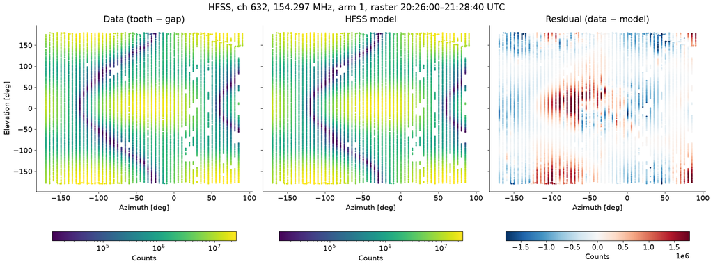

```python
plot_maps(ch-8, 'HFSS')
```

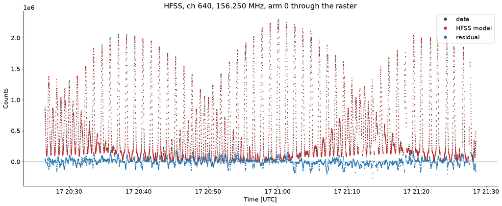

```python
plot_time(ch, 'HFSS')
```

## Empirical PCA beam, $\ell_{\max}=8$

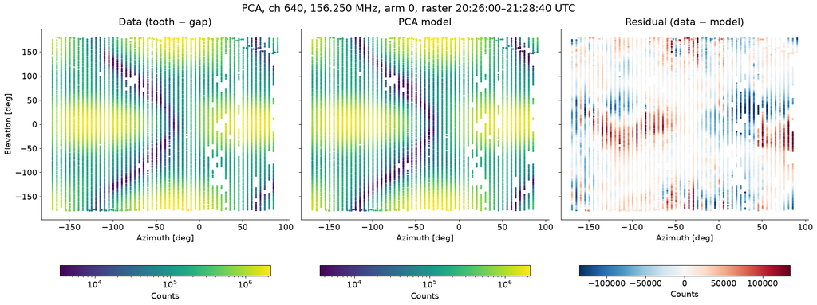

```python
plot_maps(ch, 'PCA')
```

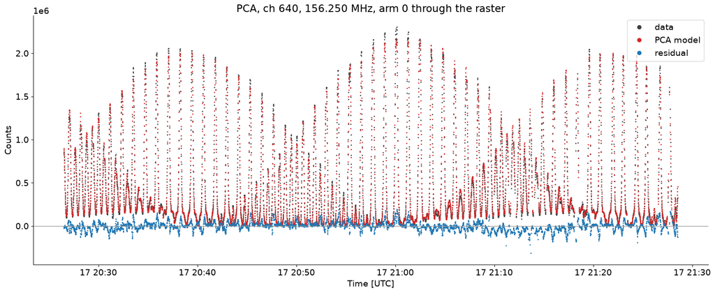

```python
plot_time(ch, 'PCA')
```

## Waterfall across the teeth

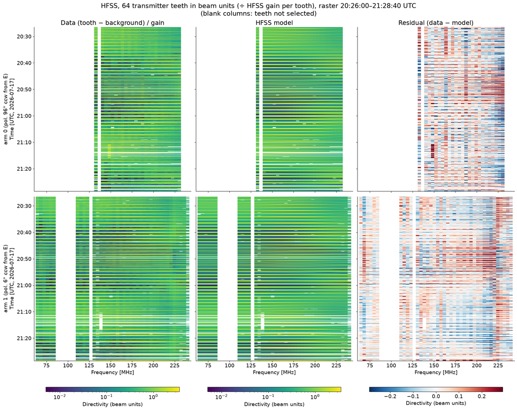

```python
plot_waterfall('HFSS')
```

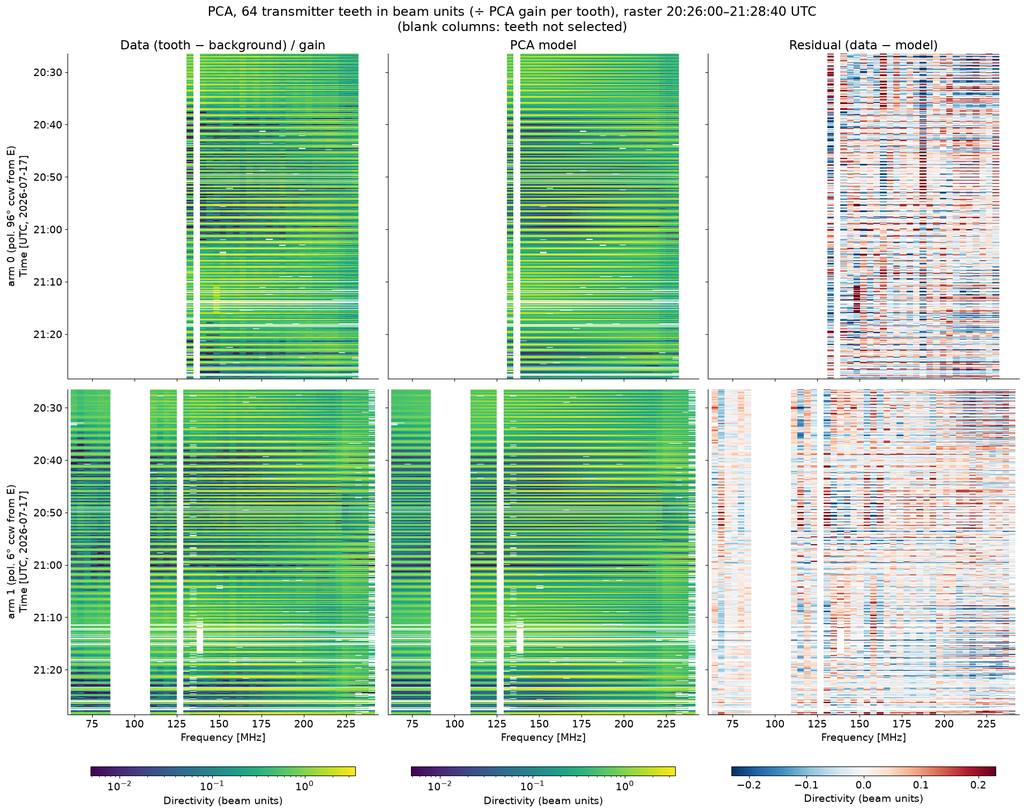

```python
plot_waterfall('PCA')
```

## Across the band

Median fractional RMS over the fitting teeth, from the product's metrics (flagged mask). Then every tooth's held-out score against frequency, by arm, with v0011 (the same fit on the 15-mode background) shown for comparison.

```python
names = {'hfss': 'HFSS (one gain per tooth)', 'pca_heldout': 'PCA, held-out fit', 'dpss_heldout': 'DPSS, held-out fit',
         'pca_exported': 'PCA, saved beam', 'dpss_exported': 'DPSS, saved beam'}
m = pd.read_csv(PRODUCT / 'metrics.csv')
m = m[m.used_for_beam_fit & m.model.isin(list(names))]
t = m.pivot_table(index='model', columns='split', values='fractional_rms', aggfunc='median')[['validation', 'test', 'all']]
t.index = [names[k] for k in t.index]
display(t.loc[list(names.values())].round(4))
```

| split | validation | test | all |
| --- | --- | --- | --- |
| HFSS (one gain per tooth) | 0.0834 | 0.0878 | 0.0908 |
| PCA, held-out fit | 0.0783 | 0.0717 | 0.0724 |
| DPSS, held-out fit | 0.0790 | 0.0705 | 0.0729 |
| PCA, saved beam | 0.0755 | 0.0693 | 0.0719 |
| DPSS, saved beam | 0.0766 | 0.0674 | 0.0728 |

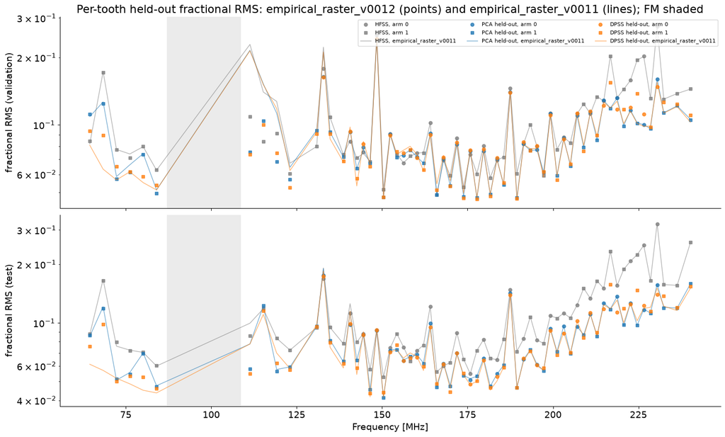

```
64 teeth shared with empirical_raster_v0011
```

| split model | empirical_raster_v0011 test | empirical_raster_v0011 validation | empirical_raster_v0012 test | empirical_raster_v0012 validation |
| --- | --- | --- | --- | --- |
| DPSS held-out | 0.0703 | 0.0810 | 0.0705 | 0.0790 |
| HFSS | 0.0886 | 0.0826 | 0.0878 | 0.0834 |
| PCA held-out | 0.0727 | 0.0805 | 0.0717 | 0.0783 |

| model band | hfss | pca_heldout | dpss_heldout |
| --- | --- | --- | --- |
| (50, 87] | 0.0757 | 0.0620 | 0.0531 |
| (87, 145] | 0.0877 | 0.0813 | 0.0792 |
| (145, 190] | 0.0718 | 0.0616 | 0.0598 |
| (190, 235] | 0.1503 | 0.0966 | 0.1073 |
| (235, 245] | 0.2073 | 0.1390 | 0.1368 |

```python
m_all = pd.read_csv(PRODUCT / 'metrics.csv')
m8 = pd.read_csv(PREVIOUS / 'metrics.csv')
fig, axes = plt.subplots(2, 1, figsize=(15, 9), sharex=True, constrained_layout=True)
styles = {'hfss': ('HFSS', 'tab:gray'), 'pca_heldout': ('PCA held-out', 'tab:blue'),
          'dpss_heldout': ('DPSS held-out', 'tab:orange')}
for ax, split in zip(axes, ('validation', 'test')):
    for key, (label, colour) in styles.items():
        for arm, marker in ((0, 'o'), (1, 's')):
            g = m_all[(m_all.model == key) & (m_all.split == split) & (m_all.arm == arm)]
            ax.semilogy(g.freq_mhz, g.fractional_rms, marker, color=colour, ms=5, alpha=0.8,
                        label='%s, arm %d' % (label, arm))
        g8 = m8[(m8.model == key) & (m8.split == split) & m8.used_for_beam_fit].sort_values('freq_mhz')
        ax.semilogy(g8.freq_mhz, g8.fractional_rms, '-', color=colour, lw=1, alpha=0.6,
                    label='%s, %s' % (label, PREVIOUS.name))
    ax.axvspan(87, 108.5, color='0.92', zorder=0)
    ax.set_ylabel('fractional RMS (%s)' % split)
axes[0].legend(ncol=3, fontsize=8)
axes[-1].set_xlabel('Frequency [MHz]')
axes[0].set_title('Per-tooth held-out fractional RMS: %s (points) and %s (lines); FM shaded' % (PRODUCT.name, PREVIOUS.name))
plt.show()

shared = sorted(set(m_all.channel) & set(m8[m8.used_for_beam_fit].channel))
rows = []
for key, (label, _) in styles.items():
    for split in ('validation', 'test'):
        a = m_all[(m_all.model == key) & (m_all.split == split) & m_all.channel.isin(shared)].fractional_rms.median()
        b = m8[(m8.model == key) & (m8.split == split) & m8.channel.isin(shared)].fractional_rms.median()
        rows.append({'model': label, 'split': split, PREVIOUS.name: b, PRODUCT.name: a})
print('%d teeth shared with %s' % (len(shared), PREVIOUS.name))
display(pd.DataFrame(rows).pivot(index='model', columns='split', values=[PREVIOUS.name, PRODUCT.name]).round(4))

band = pd.cut(m_all.freq_mhz, [50, 87, 145, 190, 235, 245])
display(m_all[m_all.split == 'test'].assign(band=band).pivot_table(
    index='band', columns=['model'], values='fractional_rms', aggfunc='median', observed=True)
    [['hfss', 'pca_heldout', 'dpss_heldout']].round(4))
```

## Findings

v0012 is v0011 refitted with a background that can represent a constant: 21 DPSS modes per window instead of 15. It is the first product of the `eigsep_data.beam_mapping` driver. The same driver with the legacy background reproduces v0011's data, masks and geometry, so any differences here come from the background alone.

## Decision

v0012 is the reference beam (Aaron, 2026-09-25), replacing v0011. The 68.4 MHz regression is known and not yet explained.

## Caveats

- **Pointing.** Commanded azimuth assumes the platform followed the motor; the evidence is in `single_ch_beam_fit_debug.ipynb`.
- **Geometry.** The selected geometry pins both transmitter-offset parameters at the ±1.06 m bound of the fit, so the transmitter position is not constrained within that bracket. The az-zero offset from the highline (−16°) is fitted. It disagrees with the known-quantities statement that the arm lies along the highline at az_pot = 0.
- **Flags.** They use the v0006 empirical beam only through a broadband per-sample level and single-sample jumps, which a smooth beam cannot absorb. Tooth-spike flags exist only for the v0006 teeth (145–235 MHz); teeth outside that range get sample flags only.
- **Background.** The 15-mode local DPSS background had about 1% bias and 2–3% scatter under a tooth, as a fraction of the sky (control test in `debug/tooth_background_debug.ipynb`); that test has not been rerun for the 21-mode basis. The error is negligible for bright teeth but not for the weak arm-0 teeth, which only just pass isolation.
- **Empirical beams.** These are exploratory, not released products. All-sample scores are in-sample, so the held-out columns are the fair comparison. The stripes are not a fresh blind test. Power-only measurements leave the absolute phase and the circular-polarization response unconstrained.
- **Signal identity.** The campaign INDEX labels this raster's every-eighth-channel signal as the instrument self-comb. Following Aaron, it is treated as the transmitter.